# API_request_project

### Execute yty_Growth

#### With Revenue

- Inputs
  - Statistic (any numeric column)
  - Tablename (any character value)
- Returns YOY Growth rate for company performance
- Creates a CTE table Last_Year that uses a lag of 4 to grab the last year quarterly results and builds that column as a new column
- The function finishes by building a Growth rate based on the newly created last year column versus the current year value.

```r
### Uses Lag to build Year over year quarterly Growth for desired columns
yty_growth <- function(statistic,table_name){
    my_conn<-dbConnect(RMariaDB::MariaDB(),
                   default.file=db_credentials,
                   group=my_sql_db)
       query <- paste("WITH Last_Year AS (SELECT Company,Report_Date,",statistic,", LAG(",statistic, ",4) Over( PARTITION BY Company ORDER BY Report_Date)  Last_Year_",statistic," FROM ",table_name,") SELECT Company,Report_Date,",statistic, ",Last_Year_",statistic,", ROUND((Last_Year_",statistic,"-",statistic,")/Last_Year_",statistic,"*-1,3) AS Growth FROM Last_Year;",sep="" )
       print(query)
    res <- dbGetQuery(my_conn,query)
    write.csv(res, file = paste("yty_growth",statistic,".csv",sep="" ))
    gc()
    dbDisconnect(my_conn)
    return(datatable(res))
}

## call function
yty_growth("Revenue","financials")
```

```
## [1] "WITH Last_Year AS (SELECT Company,Report_Date,Revenue, LAG(Revenue,4) Over( PARTITION BY Company ORDER BY Report_Date)  Last_Year_Revenue FROM financials) SELECT Company,Report_Date,Revenue,Last_Year_Revenue, ROUND((Last_Year_Revenue-Revenue)/Last_Year_Revenue*-1,3) AS Growth FROM Last_Year;…
```

|  | Company | Report_Date | Revenue | Last_Year_Revenue | Growth |
| --- | --- | --- | --- | --- | --- |
| 1 | BBT | 2009-06-30 | 1430000000 |  |  |
| 2 | BBT | 2009-09-30 | 1468000000 |  |  |
| 3 | BBT | 2009-12-31 | 1568000000 |  |  |
| 4 | BBT | 2010-03-31 | 1583000000 |  |  |
| 5 | BBT | 2010-06-30 | 1749000000 | 1430000000 | 0.223 |
| 6 | BBT | 2010-09-30 | 1654000000 | 1468000000 | 0.127 |
| 7 | BBT | 2010-12-31 | 1653000000 | 1568000000 | 0.054 |
| 8 | BBT | 2011-03-31 | 1659000000 | 1583000000 | 0.048 |
| 9 | BBT | 2011-06-30 | 1813000000 | 1749000000 | 0.037 |
| 10 | BBT | 2011-09-30 | 1856000000 | 1654000000 | 0.122 |

[output cut: 436 more lines]

#### With Operating Expenses

- Function is identical to above function
  - See Execute yty_growth with Revenue section for explanation of function

```r
yty_growth <- function(statistic,table_name){
    my_conn<-dbConnect(RMariaDB::MariaDB(),
                   default.file=db_credentials,
                   group=my_sql_db)
       query <- paste("WITH Last_Year  AS (SELECT Company,Report_Date,",statistic,", LAG(",statistic, ",4) Over( PARTITION BY Company ORDER BY Report_Date)  Last_Year_",statistic," FROM ",table_name,") SELECT Company,Report_Date,",statistic, ",Last_Year_",statistic,", ROUND((Last_Year_",statistic,"-",statistic,")/Last_Year_",statistic,"*-1,3) AS growth FROM Last_Year;",sep="" )
    print(query)
    res <- dbGetQuery(my_conn,query)
    datatable(res)
    gc()
    dbDisconnect(my_conn)
    return(datatable(res))
}

## call function
yty_growth("OperatingExpenses","financials")
```

```
## [1] "WITH Last_Year  AS (SELECT Company,Report_Date,OperatingExpenses, LAG(OperatingExpenses,4) Over( PARTITION BY Company ORDER BY Report_Date)  Last_Year_OperatingExpenses FROM financials) SELECT Company,Report_Date,OperatingExpenses,Last_Year_OperatingExpenses, ROUND((Last_Year_OperatingExpens…
```

|  | Company | Report_Date | OperatingExpenses | Last_Year_OperatingExpenses | growth |
| --- | --- | --- | --- | --- | --- |
| 1 | BBT | 2009-06-30 | 1181000000 |  |  |
| 2 | BBT | 2009-09-30 | 1320000000 |  |  |
| 3 | BBT | 2009-12-31 | 1361000000 |  |  |
| 4 | BBT | 2010-03-31 | 1341000000 |  |  |
| 5 | BBT | 2010-06-30 | 1500000000 | 1181000000 | 0.27 |
| 6 | BBT | 2010-09-30 | 1408000000 | 1320000000 | 0.067 |
| 7 | BBT | 2010-12-31 | 1421000000 | 1361000000 | 0.044 |
| 8 | BBT | 2011-03-31 | 1372000000 | 1341000000 | 0.023 |
| 9 | BBT | 2011-06-30 | 1395000000 | 1500000000 | -0.07 |
| 10 | BBT | 2011-09-30 | 1417000000 | 1408000000 | 0.006 |

[output cut: 436 more lines]

### Execute yty_ranking

#### PARTIONED BY Industry

- The query uses a CTE to build a growth rate table(Last_Year). It then uses another CTE to call Last_Year and build a growth_rate column for input statistic. Finally it uses the results FROM the 2nd CTE and runs DENSERANK of the growth_rate with the option to additionally Partition the window on industry level or Company level.
- If partition is set to 0, it will execute the query as grouped at the industry level.
- If partion is set to another integer value, it will return company level ranked results
  - The below function returns rank at the industry level

```r
yty_ranking <- function(statistic,table_name,partition=0){
    ##Build connection
    my_conn<-dbConnect(RMariaDB::MariaDB(),
                   default.file=db_credentials,
                   group=my_sql_db)

    ##Build query without partition
    if (partition==0){
    query <- paste("WITH Last_Year  AS (SELECT Company,Report_Date,",
                   statistic,", LAG(",statistic, ",4) Over( PARTITION BY Company ORDER BY Report_Date) Last_Year_",statistic,
                   " FROM ",table_name," ),", statistic,"_table AS (SELECT Company,Report_Date,",statistic,
                   ",Last_Year_",statistic,", ROUND((Last_Year_",statistic,"-",statistic,")/Last_Year_",statistic,
                   "*-1,3) AS growth FROM Last_Year) SELECT *, (CASE WHEN growth IS NOT NULL then DENSE_RANK() OVER ( ORDER BY growth desc) end) AS ranked_growth FROM ",statistic,"_table;",sep="")
    print(query)

    ## Send query request and display result
    res <- dbGetQuery(my_conn,query)
    datatable(res)
    gc()
    dbDisconnect(my_conn)
    return(datatable(res))
    }

    ##Build query with partition
    else {
        query <- paste("WITH Last_Year  AS (SELECT Company,Report_Date,",statistic,", LAG(",statistic, ",4) Over( PARTITION BY Company ORDER BY Report_Date) Last_Year_",statistic," FROM ",table_name," ),", statistic,"_table AS (SELECT Company,Report_Date,",statistic,",Last_Year_",statistic,", ROUND((Last_Year_",statistic,"-",statistic,")/Last_Year_",statistic,"*-1,3) AS growth FROM Last_Year) SELECT *, (CASE WHEN growth IS NOT NULL then DENSE_RANK() OVER ( PARTITION BY Company ORDER BY growth desc) end) AS ranked_growth FROM ",statistic,"_table;",sep="")
    print(query)
    ## Send query request and display result
    res <- dbGetQuery(my_conn,query)
    datatable(res)
    gc()
    dbDisconnect(my_conn)
    return(datatable(res))
    }
}

## call function
yty_ranking("Revenue","financials")
```

```
## [1] "WITH Last_Year  AS (SELECT Company,Report_Date,Revenue, LAG(Revenue,4) Over( PARTITION BY Company ORDER BY Report_Date) Last_Year_Revenue FROM financials ),Revenue_table AS (SELECT Company,Report_Date,Revenue,Last_Year_Revenue, ROUND((Last_Year_Revenue-Revenue)/Last_Year_Revenue*-1,3) AS gro…
```

|  | Company | Report_Date | Revenue | Last_Year_Revenue | growth | ranked_growth |
| --- | --- | --- | --- | --- | --- | --- |
| 1 | KEY | 2010-09-30 | 1032000000 | 241000000 | 3.282 | 1 |
| 2 | HBAN | 2010-09-30 | 557945000 | 143735000 | 2.882 | 2 |
| 3 | KEY | 2010-12-31 | 1252000000 | 343000000 | 2.65 | 3 |
| 4 | ZION | 2010-12-31 | 346310000 | 132057000 | 1.622 | 4 |
| 5 | HBAN | 2010-06-30 | 475893000 | 202137000 | 1.354 | 5 |
| 6 | STI | 2010-09-30 | 1670000000 | 778580000 | 1.145 | 6 |
| 7 | ZION | 2010-09-30 | 377407000 | 176990000 | 1.132 | 7 |
| 8 | KEY | 2010-06-30 | 881000000 | 452000000 | 0.949 | 8 |
| 9 | STI | 2010-12-31 | 1786000000 | 945031000 | 0.89 | 9 |
| 10 | FITB | 2010-12-31 | 1403000000 | 753000000 | 0.863 | 10 |

[output cut: 436 more lines]

#### Partioned by Company

**same function as above function**

```r
yty_ranking <- function(statistic,table_name,partition=0){
    ##Build connection
    my_conn<-dbConnect(RMariaDB::MariaDB(),
                   default.file=db_credentials,
                   group=my_sql_db)

    ##Build query without partition
    if (partition==0){
    query <- paste("WITH Last_Year  AS (SELECT Company,Report_Date,",
                   statistic,", LAG(",statistic, ",4) OVER( PARTITION BY Company ORDER BY Report_Date) Last_Year_",statistic,
                   " FROM ",table_name," ),", statistic,"_table AS (SELECT Company,Report_Date,",statistic,
                   ",Last_Year_",statistic,", ROUND((Last_Year_",statistic,"-",statistic,")/Last_Year_",statistic,
                   "*-1,3) AS growth FROM Last_Year) SELECT *, (case when growth is not null then dense_rank() OVER ( ORDER BY growth desc) end) AS ranked_growth FROM ",statistic,"_table;",sep="")
    print(query)

    ## Send query request and display result
    res <- dbGetQuery(my_conn,query)
    datatable(res)
    gc()
    dbDisconnect(my_conn)
    return(datatable(res))
    }

    ##Build query with partition
    else {
        query <- paste("WITH Last_Year  AS (SELECT Company,Report_Date,",statistic,", LAG(",statistic, ",4) OVER( PARTITION BY Company ORDER BY Report_Date) Last_Year_",statistic," FROM ",table_name," ),", statistic,"_table AS (SELECT Company,Report_Date,",statistic,",Last_Year_",statistic,", ROUND((Last_Year_",statistic,"-",statistic,")/Last_Year_",statistic,"*-1,3) AS growth FROM Last_Year) SELECT *, (case when growth is not null then dense_rank() OVER ( PARTITION BY Company ORDER BY growth desc) end) AS ranked_growth FROM ",statistic,"_table;",sep="")
    print(query)

    ## Send query request and display result
    res <- dbGetQuery(my_conn,query)
    datatable(res)
    gc()
    dbDisconnect(my_conn)
    return(datatable(res))
    }
}

## call function
yty_ranking("Revenue","financials",partition=1)
```

```
## [1] "WITH Last_Year  AS (SELECT Company,Report_Date,Revenue, LAG(Revenue,4) OVER( PARTITION BY Company ORDER BY Report_Date) Last_Year_Revenue FROM financials ),Revenue_table AS (SELECT Company,Report_Date,Revenue,Last_Year_Revenue, ROUND((Last_Year_Revenue-Revenue)/Last_Year_Revenue*-1,3) AS gro…
```

|  | Company | Report_Date | Revenue | Last_Year_Revenue | growth | ranked_growth |
| --- | --- | --- | --- | --- | --- | --- |
| 1 | BBT | 2011-12-31 | 2102000000 | 1653000000 | 0.272 | 1 |
| 2 | BBT | 2010-06-30 | 1749000000 | 1430000000 | 0.223 | 2 |
| 3 | BBT | 2012-03-31 | 2019000000 | 1659000000 | 0.217 | 3 |
| 4 | BBT | 2012-06-30 | 2155000000 | 1813000000 | 0.189 | 4 |
| 5 | BBT | 2012-09-30 | 2202000000 | 1856000000 | 0.186 | 5 |
| 6 | BBT | 2016-06-30 | 2636000000 | 2234000000 | 0.18 | 6 |
| 7 | BBT | 2010-09-30 | 1654000000 | 1468000000 | 0.127 | 7 |
| 8 | BBT | 2011-09-30 | 1856000000 | 1654000000 | 0.122 | 8 |
| 9 | BBT | 2016-09-30 | 2626000000 | 2349000000 | 0.118 | 9 |
| 10 | BBT | 2017-03-31 | 2632000000 | 2361000000 | 0.115 | 10 |

[output cut: 436 more lines]

### Execute Yearly Moving Average

```r
yearly_moving_avg <- function()
{
    my_conn<-dbConnect(RMariaDB::MariaDB(),
                   default.file=db_credentials,
                   group=my_sql_db)
    query <- paste(
    " WITH yearly_revenue AS (SELECT Company, Year(Report_Date) AS years, sum(revenue) AS revenues FROM financials GROUP BY Company,",
    "Year(Report_Date) ORDER BY Company,Year(Report_Date)) SELECT *, CASE WHEN years NOT IN (2009,2010) THEN SUM(revenues) OVER",
    "(ORDER BY Company, years ROWS BETWEEN 3 PRECEDING AND CURRENT ROW) ELSE NULL END AS 'Three_Year_Running_Avg' FROM yearly_revenue ORDER BY Company,years;", sep="" )

    ## Send query request and display result
    res <- dbGetQuery(my_conn,query)
    datatable(res)
    gc()
    dbDisconnect(my_conn)
    return(datatable(res))
}

## call function
yearly_moving_avg()
```

|  | Company | years | revenues | Three_Year_Running_Avg |
| --- | --- | --- | --- | --- |
| 1 | BBT | 2009 | 4466000000 |  |
| 2 | BBT | 2010 | 6639000000 |  |
| 3 | BBT | 2011 | 7430000000 | 18535000000 |
| 4 | BBT | 2012 | 8620000000 | 27155000000 |
| 5 | BBT | 2013 | 9060000000 | 31749000000 |
| 6 | BBT | 2014 | 8979000000 | 34089000000 |
| 7 | BBT | 2015 | 9183000000 | 35842000000 |
| 8 | BBT | 2016 | 10221000000 | 37443000000 |
| 9 | BBT | 2017 | 10770000000 | 39153000000 |
| 10 | BBT | 2018 | 10992000000 | 41166000000 |

[output cut: 111 more lines]

## EDA In R

This section is just an extremely fast overview of capabilities of R to pull in data and create tables and graphs. We are simply exploring the revenue column and some quick visualizations for EDA. Overall little time was invested, but I will gladly show more if asked

### Call SQL Database

```r
my_conn<-dbConnect(RMariaDB::MariaDB(),
                   default.file=db_credentials,
                   group=my_sql_db)
query <- "select revenue,RevenueGrowth, company, Report_date from financials"

## Send query request and display result
res <- dbGetQuery(my_conn,query)
revenue_df <- data.frame(res)
gc()
```

```
##           used (Mb) gc trigger  (Mb) max used (Mb)
## Ncells 1036662 55.4    2006685 107.2  1548993 82.8
## Vcells 1837535 14.1    8388608  64.0  2995184 22.9
```

```r
dbDisconnect(my_conn)
```

### Tables

**Table of Revenue and Growth of Big Banks**

|  | revenue | RevenueGrowth | company | Report_date |
| --- | --- | --- | --- | --- |
| 1 | 1430000000 | -0.0863 | BBT | 2009-06-30 |
| 2 | 388000000 | -0.2451 | CMA | 2009-06-30 |
| 3 | 2373000000 | 2.2024 | FITB | 2009-06-30 |
| 4 | 202137000 | -0.6001 | HBAN | 2009-06-30 |
| 5 | 452000000 | 0.7519 | KEY | 2009-06-30 |
| 6 | 626216000 | -0.048 | MTB | 2009-06-30 |
| 7 | 3803000000 | 0.8651 | PNC | 2009-06-30 |
| 8 | 1199151000 | -0.4348 | STI | 2009-06-30 |
| 9 | 2714000000 | -0.1441 | USB | 2009-06-30 |
| 10 | 17421000000 | 1.0621 | WFC | 2009-06-30 |

[output cut: 436 more lines]

**Table of Total Revenue From 2009-2019 of Big Banks**

| company | total_revenue |
| --- | --- |
| WFC | 795758000000 |
| USB | 184094000000 |
| PNC | 161516000000 |
| BBT | 91973000000 |
| STI | 76026762000 |
| FITB | 60527000000 |
| KEY | 44725000000 |
| MTB | 43827760000 |
| HBAN | 29365887000 |
| CMA | 26165000000 |
| ZION | 21116056000 |

**Table of Average Quarterly Revenue From 2009-2019 of Big Banks**

| company | avg_quarterly_revnue |
| --- | --- |
| WFC | 19893950000 |
| USB | 4490097561 |
| PNC | 3939414634 |
| BBT | 2243243902 |
| STI | 1900669050 |
| FITB | 1513175000 |
| MTB | 1095694000 |
| KEY | 1090853659 |
| HBAN | 716241146 |
| CMA | 638170732 |
| ZION | 527901400 |

**Table of Cumulative Sum of Revenue From 2009-2019 of Big Banks**

|  | company | Report_date | value | cum_sum_revenue_in_billions |
| --- | --- | --- | --- | --- |
| 1 | BBT | 2009-06-30 | 1430000000 | 1.43 |
| 2 | BBT | 2009-09-30 | 1468000000 | 2.898 |
| 3 | BBT | 2009-12-31 | 1568000000 | 4.466 |
| 4 | BBT | 2010-03-31 | 1583000000 | 6.049 |
| 5 | BBT | 2010-06-30 | 1749000000 | 7.798 |
| 6 | BBT | 2010-09-30 | 1654000000 | 9.452 |
| 7 | BBT | 2010-12-31 | 1653000000 | 11.105 |
| 8 | BBT | 2011-03-31 | 1659000000 | 12.764 |
| 9 | BBT | 2011-06-30 | 1813000000 | 14.577 |
| 10 | BBT | 2011-09-30 | 1856000000 | 16.433 |

[output cut: 436 more lines]

### Graphs

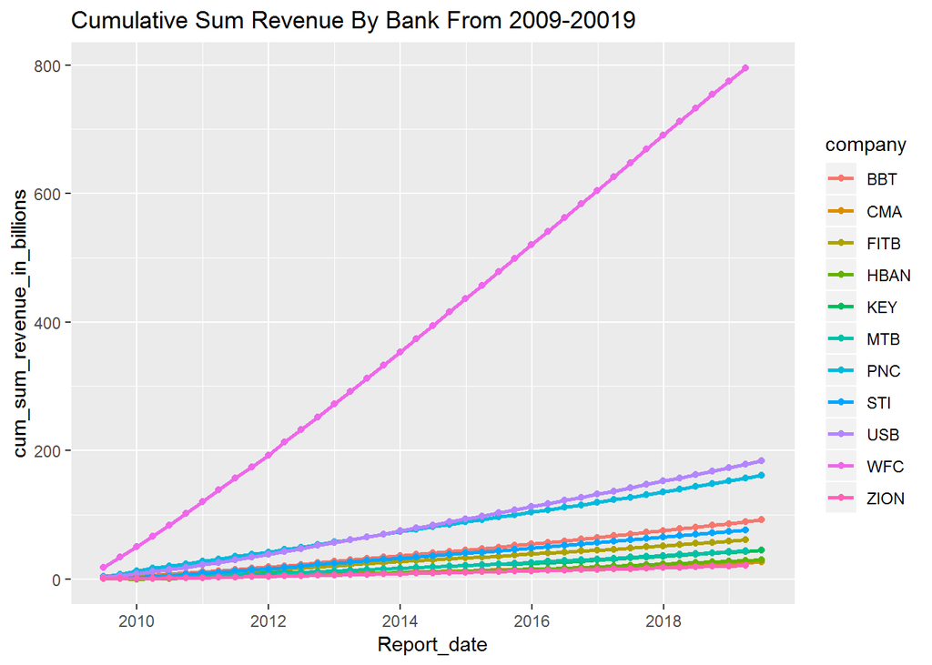

We can see that Wells Fargo is way too large and it effects our comparisons. Lets exclude Wells Fargo

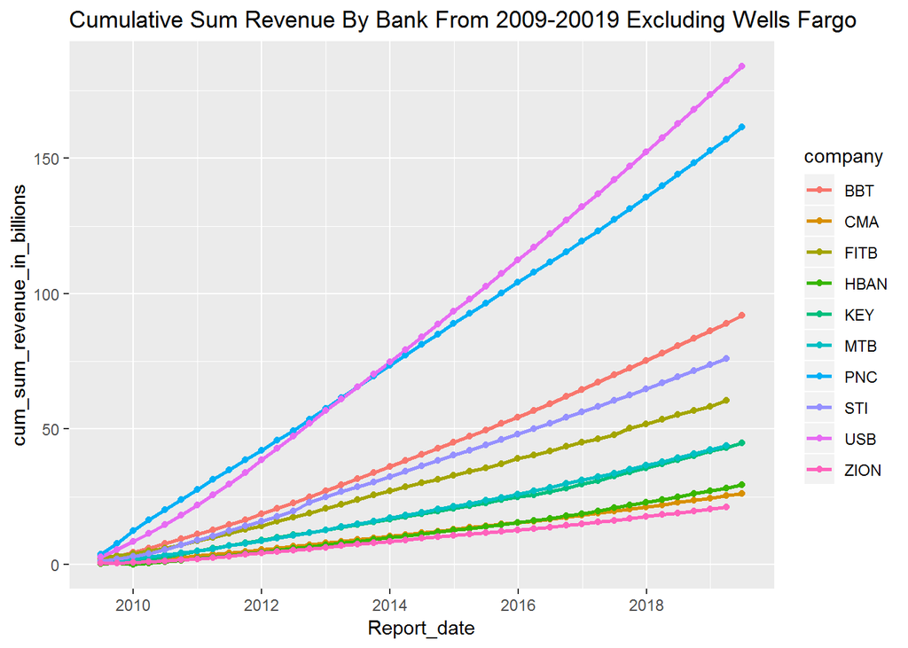

While the cumulative sum can give us a picture of overall strength in the market and while it appears some banks broke away around 2011, looking at quarterly revenue could yield more fruitful.

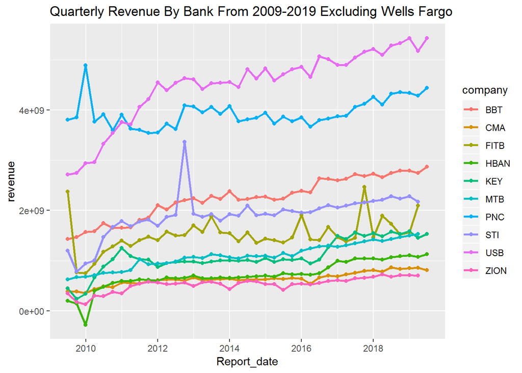

```r
revenue_df <- revenue_df %>%
  arrange(company, Report_date) %>%
  group_by(company) %>%
  mutate(last_year = lag(revenue,4)) %>%
  ungroup() %>%
  mutate(growth=round((last_year-revenue)/last_year*-1,3))

## Growth table
datatable(revenue_df)
```

|  | revenue | RevenueGrowth | company | Report_date | last_year | growth |
| --- | --- | --- | --- | --- | --- | --- |
| 1 | 1430000000 | -0.0863 | BBT | 2009-06-30 |  |  |
| 2 | 1468000000 | -0.0317 | BBT | 2009-09-30 |  |  |
| 3 | 1568000000 | 0.1667 | BBT | 2009-12-31 |  |  |
| 4 | 1583000000 | 0.0546 | BBT | 2010-03-31 |  |  |
| 5 | 1749000000 | 0.2231 | BBT | 2010-06-30 | 1430000000 | 0.223 |
| 6 | 1654000000 | 0.1267 | BBT | 2010-09-30 | 1468000000 | 0.127 |
| 7 | 1653000000 | 0.0542 | BBT | 2010-12-31 | 1568000000 | 0.054 |
| 8 | 1659000000 | 0.048 | BBT | 2011-03-31 | 1583000000 | 0.048 |
| 9 | 1813000000 | 0.0366 | BBT | 2011-06-30 | 1749000000 | 0.037 |
| 10 | 1856000000 | 0.1221 | BBT | 2011-09-30 | 1654000000 | 0.122 |

[output cut: 396 more lines]

```r
## Compare growth table to tables existing growth rate
table((revenue_df$RevenueGrowth - revenue_df$growth)<.001)
```

```
##
## FALSE  TRUE
##     1   365
```

Then we can graph growth rate

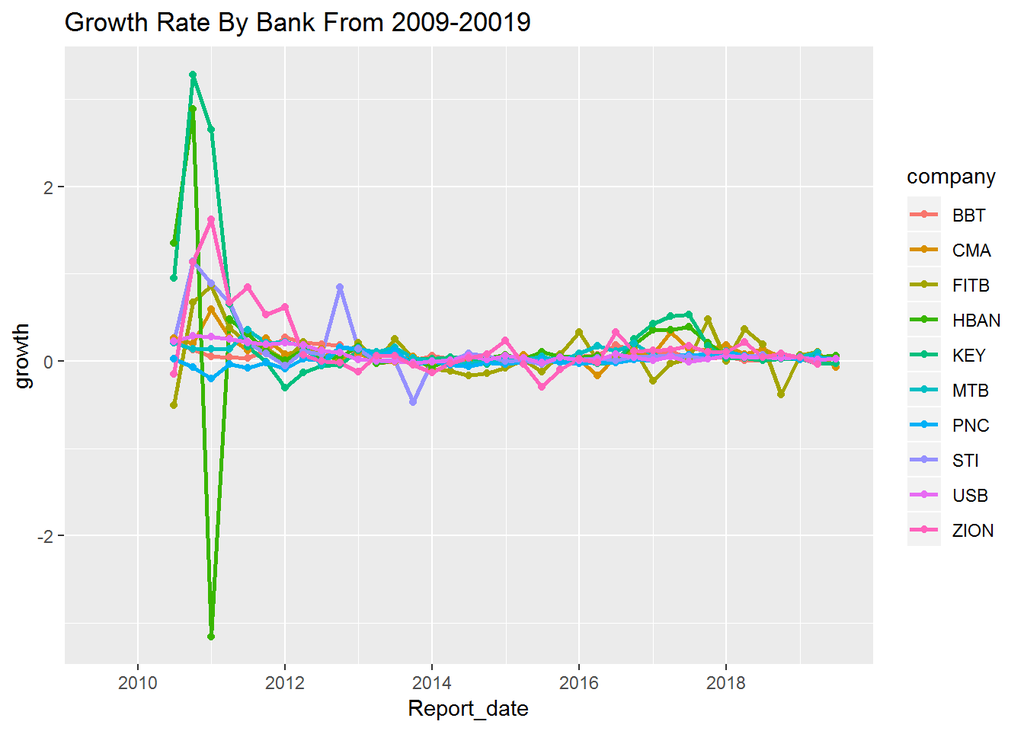

Our graph allows us to see that there were some intense swings in the growth rate of HBAN and KEY My assumption would be they have relatively small cap sizes, or they experienced prolonged damage from the recession. We can explore their cap size relative to other banks. Another thing to explore would be filtering this from 2012 forward to get a better idea of swings minus huge outliers and getting several years removed from recession. We can also explore all negative growth rate quarters and see if there were any patterns. We would likely want to build individual graphs of these banks as well.

| company | sum_revenue |
| --- | --- |
| PNC | 42044000000 |
| USB | 38519000000 |
| BBT | 18535000000 |
| STI | 15827762000 |
| FITB | 14279000000 |
| KEY | 8878000000 |
| MTB | 8688000000 |
| CMA | 5386000000 |
| HBAN | 4532340000 |
| ZION | 4147812000 |

Graphing HBAN and KEY only

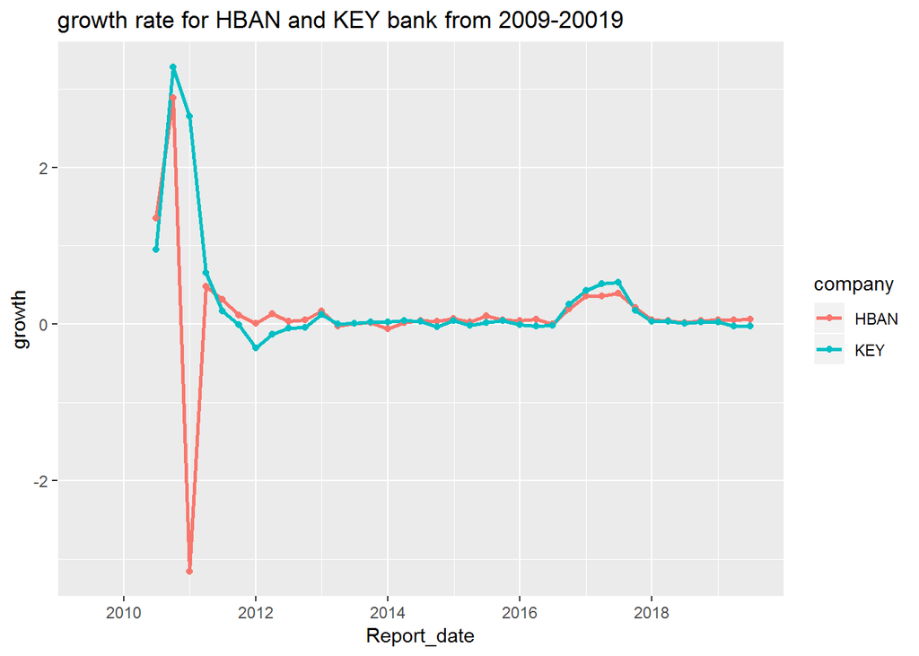

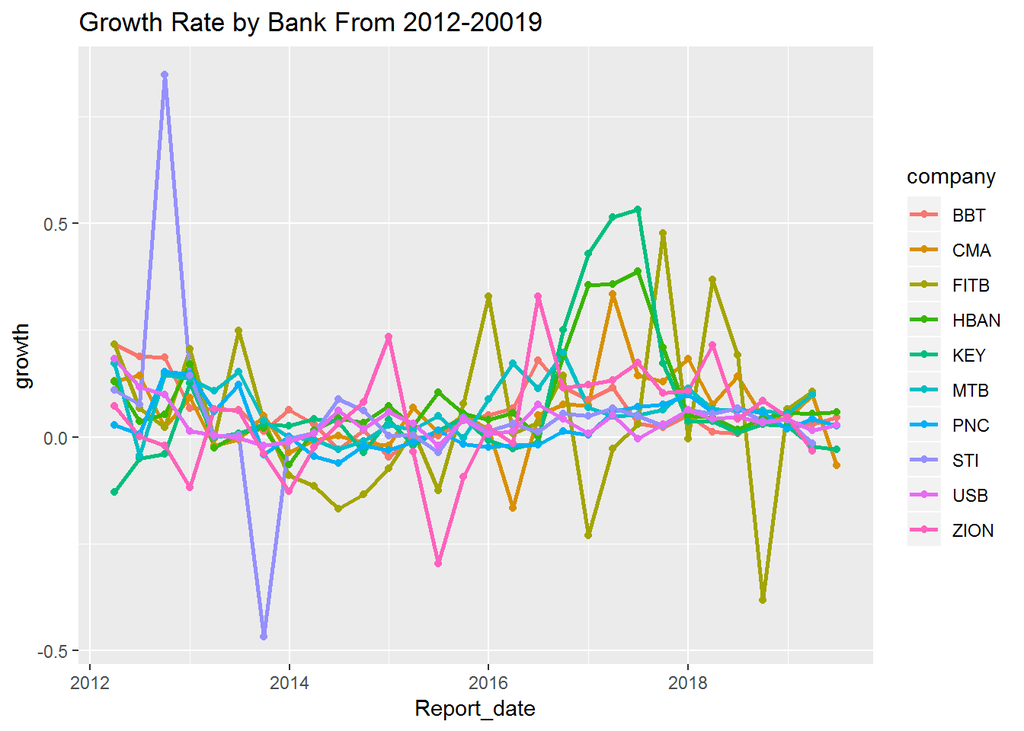

Getting only negative growth rates

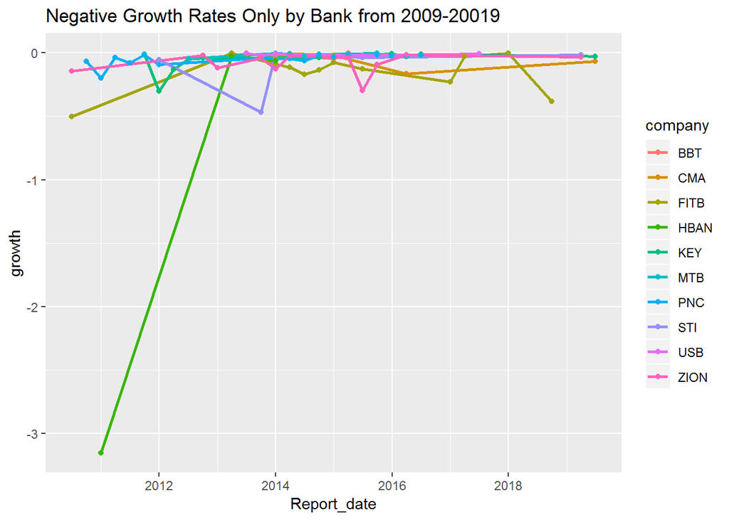

### Animated Cumulative Revenue Race

- animation tracks cumulative revenue from 2009 through 2018.
- data is complete so no cartesian join was needed and I think its a cool way of visualizing campaign success.
- If we want to show a client how they have increased growth in some field versus the industry as a whole, this graph can show them where they started and the success and process of things we implemented to get them to where they are now relative to competitors .

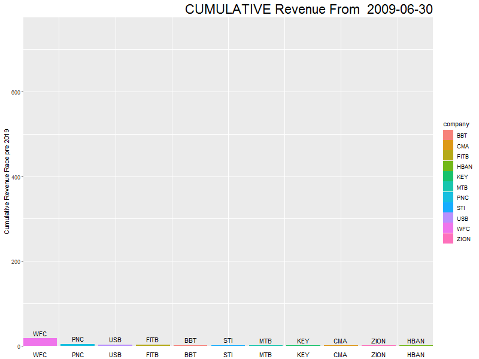

```r
library(plotly)
library(gganimate)

cumsum_revnue <- cumsum_revnue %>%
  ungroup() %>%
  arrange(Report_date) %>%
  mutate(company= as.factor(company)) %>%
  filter(year(Report_date)<2019) %>%
  group_by(Report_date) %>%
  mutate(ordering = min_rank(-cum_sum_revenue_in_billions * 1.0)) %>%
  ungroup()

# animated  barplot Race for cumulative revenue:
my_animation <- cumsum_revnue %>%
  ggplot( aes(x=ordering,group = company,fill=company)) +
#  geom_bar(stat='identity')+
geom_tile(aes(y =cum_sum_revenue_in_billions/2 ,
                height = cum_sum_revenue_in_billions,
                width = 0.9), alpha = 0.9) +
  geom_text(aes(y = cum_sum_revenue_in_billions, label = company), vjust = -0.5) +
  # text in x-axis (requires clip = "off" in coord_cartesian)
  geom_text(aes(y = 0, label = company), vjust = 2) +
  ylab("Cumulative Revenue Race pre 2019") +
  coord_cartesian(clip = "off", expand = FALSE) +
  labs(title=paste("CUMULATIVE Revenue From  {closest_state}"), x = "") +
  theme(plot.title = element_text(hjust = 1, size = 22),
        axis.ticks.x = element_blank(),
        axis.text.x  = element_blank()) +
  transition_states(Report_date,
                    transition_length = 2, state_length = 1)

animate(my_animation, 200, fps = 10, duration = 25, width = 800, height = 600, renderer = gifski_renderer("animation/this.gif") )
```